# Distributions Fitting

Hector Mathonsi

13 October 2024

# 1 Scenario

At a clothing manufacturing company, a machine is set to produce a certain type of cloth in 10m rolls. As part of the quality control process, the manager selects a random sample of rolls from the weekly production to test the quality of the cloth, and records the following information:

- Breaking strength of the cloth in pounds per square inch (psi)
- Number of flaws per roll of cloth

The `cloth.csv` dataset shows the data for a random sample of n = 65 rolls of cloth.

# 2 Load the Data

```r
cloth <- read.csv("../data/cloth.csv", header = TRUE)
cloth
```

| BreakStrenght | NumFlaw |
| --- | --- |
| 69.0 | 2 |
| 70.9 | 1 |
| 84.7 | 2 |
| 68.7 | 3 |
| 75.4 | 1 |
| 70.7 | 2 |
| 68.5 | 3 |
| 75.0 | 1 |
| 60.7 | 0 |
| 71.7 | 2 |

[output cut: 55 more lines]

# 3 Fit the Normal Distribution

It is generally assumed that the breaking strength of this type of cloth is normally.

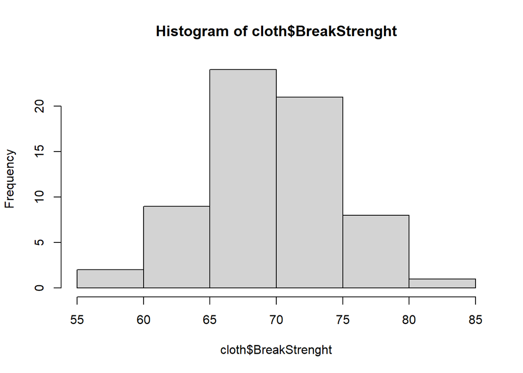

```r
# Histogram
hist(cloth$BreakStrenght)
```

## 3.1 Standardize the Data

Standardise the breaking strength variable using the sample information. Plot the empirical distribution function together with the curve of the theoretical cdf in a different colour.

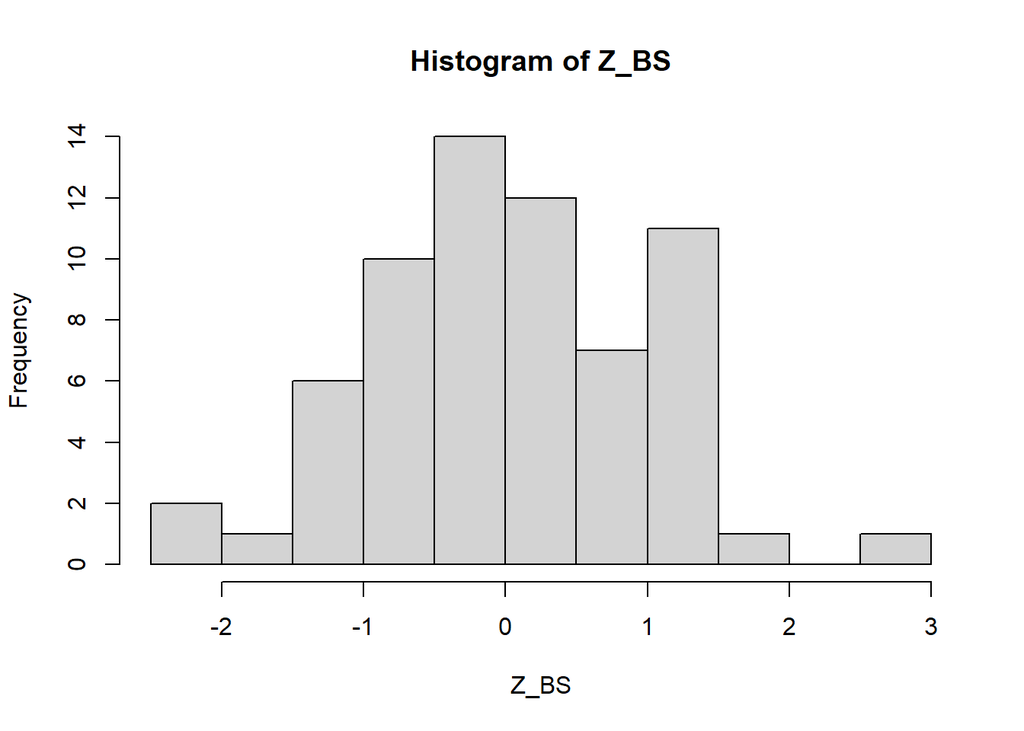

```r
Z_BS <- (cloth$BreakStrenght - mean(cloth$BreakStrenght))/sd(cloth$BreakStrenght)
hist(Z_BS)
```

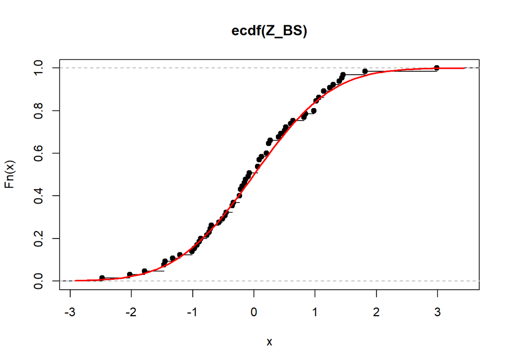

```r
plot(ecdf(Z_BS))
curve(pnorm, add = T, col = "red", lwd = 2)
```

# 4 Chi-Squared Goodness-of-Fit Test

It is assumed that the number of flaws per 10m roll of cloth (X) follows a Poisson distribution with lambda equal to 1.2. Use the Chi-squared goodness-of-fit hypothesis test to test whether the number of flaws per 10m roll of cloth follows a Poisson distribution with parameter 1.2. Check that the minimum expected frequency is at least 5.

```r
# Frequency table
observed_freq <- table(cloth$NumFlaw)
observed_freq
```

```
 0  1  2  3
11 22 20 12
```

```r
# Poisson Prob
poisson_prob <- dpois(0:2, lambda = 1.2)
poisson_prob <- c(poisson_prob, 1-sum(poisson_prob))
poisson_prob
```

```
[1] 0.3011942 0.3614331 0.2168598 0.1205129
```

```r
sum(poisson_prob)
```

```
[1] 1
```

```r
# Chi-Squared Goodness-of-Fit Test
chi_test <- chisq.test(x = observed_freq, p = poisson_prob)
chi_test
```

```
    Chi-squared test for given probabilities

data:  observed_freq
X-squared = 8.5423, df = 3, p-value = 0.03604
```